# ReadyProjectOne

Oamar Gianan

October 10, 2016

# Twitter Network Exploration

### A visual exploration of tweets on NASDAQ 100 stocks

## About the Dataset

- Source:
  - [Follow The Hashtag](http://followthehashtag.com/datasets/nasdaq-100-companies-free-twitter-dataset/)
- Measured time:
  - From 2016 March 28th to 2016 June 15th
  - 79 days
- Format:
  - 6 Excel files per company
- Twitter Stream:
  - Included in “Dashboad” file in Sheet named Stream
  - Retweets are included in this datasets
- Size:
  - 178 Mb (compressed)

## Questions

As a network analysis, I wanted to find out the following:

- Who are the top influentials?
- Who is the most influential user?
- Which stocks are the most influential users talking about?
- Which events caused the most chatter?
- Is there a corellation between stock movement and number of tweets? Which stock causes more people to tweet?
- Is there early chatter before significant price movements?

## Preparing the Dataset

- Dataset was organized per company
- 103 companies with six excel files each
  - Discovery Communications has two listings: $DISCA, $DISCK
  - Alphabet, Inc. (Google) has two listings: $GOOGL, $GOOG
  - Liberty Global has two listings: $LBTYA, $LBTYK
- Twitter stream was listed in the second sheet in one of the excel files

### BASH Scripting

Excel files were in nested zip files.

This is the bash script to automate unzipping and organize all excel files with the tweet stream into one folder

```bash
#/bin/sh

mkdir all/
for file in *.zip
    do
    unzip "$file" -d all
done

cd all/
mkdir sheets/
for zips in *.zip
    do
    unzip "$zips" -d sheets/
done

cd sheets/
mkdir dashboards/
for sheets in export_dash*
    do
    mv "$sheets" dashboards/
done
```

### Converting xlsx to csv

Found python utility which easily converts xlsx files to csv. Supports conversion of xlsx files with multiple sheets. Can be automated using bash scripting also.

This is the bash script to convert multiple xlsx files to csvs.

```bash
#/bin/sh
mkdir csv/
for dash in expo*
    do
    xlsx2csv -s 2 "$dash" csv/"${dash%.*}".csv
done
```

### Preparing the Raw Stream Dataframe

Initial library calls.

```r
library(readr)
library(dplyr)
```

```r
library(ggplot2)
library(data.table) # for frank function
library(knitr)
library(plyr)
library(VennDiagram)
library(corrplot)
library(wordcloud)
library(lubridate)
library(stringr)
library(tidyr)
library(igraph)
options(scipen = 100)
#library(network)
#library(sna)
#library(qdap)
#library(tm)
```

### Loading multiple csv into a single dataframe.

### Saving the object for later use.

readRDS is a temporary code chink for troubleshooting RMarkdown. REMOVE WHEN DONE

## The Dataset

### Number of unique users (based on Nickname)

```r
length(unique(stream$Nickname))
```

```
## [1] 431
```

```r
NicknameList <- as.data.frame(unique(stream$Nickname))
names(NicknameList) <- 'Nickname'
```

### Number of unique tweets (based on Tweet Id, RTs recieve a unique Tweet ID too)

```r
length(unique(stream$`Tweet Id`))
```

```
## [1] 1316
```

### The Most Talked About Stock

```r
allSymbols  <- stream %>% select(Symbols)
```

```r
allSymbols <- toupper(unlist(strsplit(allSymbols$Symbols, ',')))
```

Tabulate occurences and convert to data frame

```r
SymFreq <- as.data.frame(table(allSymbols), stringsAsFactors = FALSE)
names(SymFreq) <- c('Symbol', 'Freq')
```

```r
png(filename = "wordcloud.png")
wordcloud(
       words = SymFreq$Symbol,
       freq = SymFreq$Freq,
       scale=c(4,.5),
       min.freq = 3,
       max.words=100,
       random.order=FALSE,
       rot.per=0.35,
       colors=brewer.pal(8, "Dark2")
       )
dev.off()
```

### Significant Events

When was there the most tweets?

```r
#for zooming into dates on durationDist
#zoom <- as_date(c("2016-04-25","2016-05-01"))
zoom <- NULL

durationDist = ggplot(
                     stream,
                     aes(Date)
                     ) +
              geom_density(
                     aes(fill = `Is a RT`),
                     alpha = 0.5
                     ) +
              scale_fill_discrete(
                     guide = 'none'
                     ) +
              scale_x_date(
                     name = "2016",
                     date_labels = "%b %d",
                     date_breaks = "2 weeks",
                     date_minor_breaks = "1 week",
                     limits = zoom
                     ) +
              xlab(
                     'All tweets'
                     )
png(filename = "freqStream.png")
       plot(durationDist)
dev.off()
```

Verifying by code, we get the date with the most tweets.

```r
twperday <- stream %>% group_by(.,Date) %>% dplyr::summarise(.,Tweets=n())

maxday <- twperday[which.max(twperday$Tweets), ]
```

```r
event <- subset(stream, month(stream$Timestamp) == month(maxday[[1]]) &
                     day(stream$Timestamp) == day(maxday[[1]]))

timeofdayDist = ggplot(
                     event,
                     aes(Timestamp)
                     ) +
                     geom_density(
                            aes(fill = `Is a RT`),
                            alpha = 0.5
                            ) +
                     scale_fill_discrete(guide = 'none') +
                     xlab('All tweets')
png(filename = "freqMaxday.png")
       plot(timeofdayDist)
dev.off()
```

Verifying by code

```r
#how to group into chunks of 15 minutes. or variable minutes?
#<check out cut.Date to factorize a continuous variable like time/date>

timeofday <- event %>% group_by(.,hour(event$Timestamp)) %>% dplyr::summarise(.,Tweets=n())

timeofday[which.max(timeofday$Tweets), ]
```

```
## # A tibble: 1 × 2
##   `hour(event$Timestamp)` Tweets
##                     <int>  <int>
## 1                      13     21
```

## Measure of Influence

Three measures of influence:

1. Indegree influence.
   - The number of people who follow a user.
   - Directly indicates the audience size of the user.
2. Retweet influence.
   - The number of times others “forward” a user’s tweet.
   - Represents the ability of the user to create content with pass-along value.
3. Mention.
   - The number of times others mention a user’s name.
   - Represents the ability of the user to engage others in a conversation.

> **Why are FAVS or LIKES not included?** *Influence is measured by the spread of information from the source into the network. A tweet that the user liked is not shared to the user’s followers; Also, the user’s followers cannot know which tweets the user liked. Liking or Faving does not induce flow of information. A liked tweet is more likely to be retweeted anyway.*

### Ranking

[Fractional rank](https://en.wikipedia.org/wiki/Ranking)

- Rank of 1 is given to the most influential user and increasing rank indicates a less influential user. Users with the same influence score recieves the average of the rank amongst them.

### Deriving Indegree influence rank

Get data frame of unique users, disregard users with 0 followers:

```r
indegRanked <- stream %>%
       filter(duplicated(Nickname) == FALSE) %>%
       select(Nickname, Followers)

saveRDS(indegRanked, file = "indegRanked.RDS")
```

431 out of 431 unique users had followers > 0. 0 users disregarded.

Adding fractional rank column to data frame.

```r
IndegRank <- frank(indegRanked, -Followers, ties.method = 'average')
indegRanked$IndegRank <- IndegRank
```

### Deriving Retweet influence rank

Get data frame of usernames and their total number of retweets.

```r
##sum(RTs) returns sum of ALL tweets and not the sum of group_by
# RTtotalPerNick <-0
# retw_all <- stream %>%
#        filter(`Is a RT` == FALSE & !is.na(RTs))  %>%
#        filter(duplicated(`Tweet Id`) == FALSE)  %>%
#        group_by(Nickname) %>%
#        mutate(RTtotalPerNick = sum(RTs))

retw_all <- stream %>%
       filter(`Is a RT` == FALSE & RTs > 0)  %>%
       select(Nickname, RTs)

retwRanked <- aggregate(retw_all$RTs, by = list(retw_all$Nickname), FUN = sum)

names(retwRanked) <- c('Nickname', 'TotalRT')
```

Consolidating users with 0 RTs

```r
retwRanked <- right_join(retwRanked, NicknameList, by = 'Nickname')
retwRanked <- retwRanked %>% mutate(TotalRT = ifelse(is.na(TotalRT),0,TotalRT))
```

Adding fractional rank column to data frame:

```r
retwRank <- frank(retwRanked, -TotalRT, ties.method = 'average')
retwRanked$retwRank <- retwRank

saveRDS(retwRanked, file = "retwRanked.RDS")
###WHY IS THIS NOT WORKING???
#retwRanked <- u_RTtotal %>%
#       mutate(retwRank = frank(-RTtotalPerNick, ties.method = 'average'))
```

## Deriving Mention influence rank

Get data frame of unique tweets with mentions.

```r
mentionRanked <- stream %>%
       filter(`Is a RT` == FALSE & !is.na(`User Mentions`)) %>%
       select(`User Mentions`)
```

Convert data frame to vector to be able to split multiple mentions and remove @ symbol

```r
mentionRanked <- gsub('@','', as.vector(mentionRanked[['User Mentions']]))
mentionRanked <- unlist(strsplit(mentionRanked, ','))
```

Tabulate occurences and convert to data frame

```r
mentionRanked <- as.data.frame(table(mentionRanked), stringsAsFactors = FALSE)
names(mentionRanked) <- c('Nickname', 'TotalMentions')
```

Consolidating users with 0 mentions

```r
mentionRanked <- right_join(mentionRanked, NicknameList, by = 'Nickname')
mentionRanked <- mentionRanked %>%
       mutate(TotalMentions = ifelse(is.na(TotalMentions),0,TotalMentions))
```

Adding fractional rank column to data frame:

```r
menRank <- frank(mentionRanked, -TotalMentions, ties.method = 'average')
mentionRanked$menRank <- menRank


saveRDS(mentionRanked, file = "all_mentionRanked.RDS")
```

## The Top Influentials

```r
indegTops <- as.data.frame(indegRanked) %>%
       arrange(IndegRank) %>% select(Rank = IndegRank, TopIndegree = Nickname)
rtTops <- as.data.frame(retwRanked) %>%
       arrange(retwRank) %>% select(Rank = retwRank, TopRT = Nickname)
menTops <- as.data.frame(mentionRanked) %>%
       arrange(menRank) %>% select(Rank = menRank, TopMentions = Nickname)

#Convert Rank column to Int
#Normalizing the list
class(indegTops$Rank) <- "integer"

rtTops$Rank <- 1:dim(retwRanked)[1]

menTops$Rank <- 1:dim(mentionRanked)[1]

#Join data frames
topInf <- left_join(left_join(indegTops,rtTops, by = 'Rank'), menTops, by = 'Rank')

saveRDS(topInf, file = "topInfTable.RDS")

kable(topInf[1:30, ], caption = 'Top 30 Influencers per Category')
```

Top 30 Influencers per Category

| Rank | TopIndegree | TopRT | TopMentions |
| --- | --- | --- | --- |
| 1 | CBOE | WrigleyTom | Benzinga |
| 2 | InvestorIdeas | ppprophet | InvestirFr |
| 3 | 247WallSt | TradeZer0 | AlertTrade |
| 4 | androsForm | LMTentarelli | LMTentarelli |
| 5 | jjjinvesting | eWhispers | AdaptToReality |
| 6 | AlertTrade | PersonsPlanet | Opinterest |
| 7 | DirectorsTalk | Boursier_com | eWhispers |
| 8 | PENNYBUSTER1 | bored2tears | Le_Revenu |
| 9 | scottrade | pnoytrader | TransitoOK |
| 10 | MorningstarInc | crosshairtrader | DozenStocks |
| 11 | Quaikey | UTradePH | IHPosts2 |
| 12 | PersonsPlanet | OpenOutcrier | leahanneta |
| 13 | Benzinga | quack1612 | jascapital1 |
| 14 | airtransat | MorningstarInc | Jascapitalforex |
| 15 | traderstewie | SleekMoneycom | XFenaux |
| 16 | OptionAlert | App_sw_ | AmericanBanking |
| 17 | KimAuclair | DividendSheet | ConsumerFeed |
| 18 | stt2318 | InvestirFr | SleekMoneycom |
| 19 | AltruistWealth | iviewmarkets | desota |
| 20 | MarketCurrents | ChinaInvest | dailypoliticaln |
| 21 | selfmade_harris | 1MinuteStock | saidjarrah |
| 22 | jfahmy | ACInvestorBlog | Boursier_com |
| 23 | daytradingninja | Benzinga | TickerReport |
| 24 | OpenOutcrier | gouluk1 | Allstocknews |
| 25 | Briefingcom | DimitriDelmonD | confcalltran |
| 26 | InvestirFr | DozenStocks | EnergieBahn |
| 27 | ProTrader_Mike | SAlphaTech | thelegacynewswi |
| 28 | ACInvestorBlog | TCENTRAL_FR | crosshairtrader |
| 29 | WrigleyTom | capitalico | stockfollower4u |
| 30 | stockchartscom | Grainwiz | bn201612 |

```r
### TRY TO VECTORIZE THIS LATER

findInt = function(topN){
       len <- 0
       inc <- 0
       while (len < topN){
              len <- length(intersect(intersect(indegTops[1:inc, 2], rtTops[1:inc, 2]),
                                      menTops[1:inc, 2]))
              inc <- inc +1
       }
       return(inc-1)
}

findNames = function(int){
       intersect(intersect(indegTops[1:int, 2], rtTops[1:int, 2]), menTops[1:int, 2])
}
```

```r
### TRY TO VECTORIZE THIS LATER

findRTMen = function(topN){
       len <- 0
       inc <- 0
       while (len < topN){
              len <- length(intersect(menTops[1:inc, 2], rtTops[1:inc, 2]))
              inc <- inc +1
       }
       return(inc-1)
}

findRTMenNames = function(int){
       intersect(menTops[1:int, 2], rtTops[1:int, 2])
}
```

```r
topVenn <- topInf[1:100, ]

xt <- list("Indegree" = topVenn$TopIndegree, "Retweet" = topVenn$TopRT, "Mentions" = topVenn$TopMentions)

venn.diagram(
       xt,
       height = 800,
       width = 800,
       euler.d = TRUE,
       scaled = TRUE,
       imagetype = "png",
       filename = "top100Venn.png",
       lty = "blank",
       cex = 0.25,
       cat.cex = 0.25,
       fill = c("skyblue", "pink1", "mediumorchid")
)
```

```
## [1] 1
```

## Figure 1. Venn diagram of the top 100 influentials across measures.

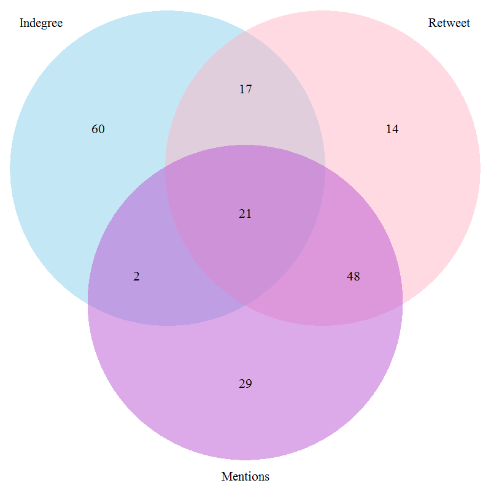

## Spearman’s Correlation Coefficient

```r
c.test <- right_join(right_join(indegRanked, mentionRanked, by = 'Nickname'),
                     retwRanked, by = 'Nickname')

test.c <- c.test %>% arrange(IndegRank) %>%
       select(IndegRank, menRank, retwRank) %>% top_n(-10000, wt = IndegRank)

spcor <- cor(test.c, method = 'spearman')

png(filename = "corrplot.png")

corrplot(
       spcor,
       method = 'circle',
       outline = FALSE,
       type = 'upper',
       tl.col = "black"
       )
dev.off()
```

This means that in most cases, users who are retweeted often are also mentioned often, and vice versa.